# Tarea6_Denis_Rodriguez

### Tarea #6

#### Ejercicio 1: [20 puntos]

Supongamos que tenemos un modelo predictivo para detectar Fraude en Tarjetas de Crédito, la variable a predecir es Fraude con dos posibles valores Sí (para el caso en que sí fue fraude) y No (para el caso en que no fue fraude).

#### a-) Calcule a mano o en Excel la Precisión Global, la Precisión Positiva, la Precisión Negativa, los Falsos Positivos, los Falsos Negativos, la Asertividad Positiva y la Asertividad Negativa.

Presición global 0.9892939471

Precisión Positiva 0.0033632287

Precisión Negativa 0.9998558836

Falsos Positivos 0.0001441164461

Falsos Negativos 0.9966367713

Asertividad Positiva 0.2

Asertividad Negativa 0.9894346529

#### b-) ¿Es bueno o malo el modelo predictivo? Justifique su respuesta.

El modelo predictivo es malo si se desea identificar personas que sí cometieron fraude, pero seria un buen modelo para identificar personas que no cometieron fraude, debido a que el modelo tiene una presición alta en ese aspecto. Debido a que se trata de un modelo para identificar fraude, el mismo no es un buen modelo ya que la asertividad positiva es muy baja.

#### Pregunta 2: [40 puntos]

Esta pregunta utiliza los datos sobre la conocida historia y tragedia del Titanic, usando los datos (titanic.csv) de los pasajeros se trata de predecir la supervivencia o no de un pasajero. La tabla contiene 12 variables y 1309 observaciones

#### a-) Cargue la tabla de datos titanic.csv en Python. Asegúrese re-codificar las variables cualitativas y de ignorar variables que no se deben usar.

```python
import os
import pandas as pd
import numpy as np
import matplotlib.pyplot as plt
from sklearn.model_selection import train_test_split
from sklearn.neighbors import KNeighborsClassifier
from sklearn.metrics import confusion_matrix

os.chdir("/home/denis/git_projects/MineriaDatos/csv/")
datos_titanic = pd.read_csv('Titanic.csv',delimiter=',',decimal=".")

def calculosMatriz(MC):
    precision_global = np.sum(MC.diagonal()) / np.sum(MC)
    precision_positiva = MC[1][1]/(MC[1][0]+MC[1][1])
    precision_negativa = MC[0][0]/(MC[0][1]+MC[0][0])
    falsos_positivos = MC[0][1]/(MC[0][1]+MC[0][0])
    falsos_negativos = MC[1][0]/(MC[1][0]+MC[1][1])
    acertividad_positiva = MC[1][1]/(MC[0][1]+MC[1][1])
    acertividad_negativa = MC[0][0]/(MC[1][0]+MC[0][0])
    return {"Matriz de confusión ":MC,
            "Precisión global":precision_global,
            "Precisión positiva":precision_positiva,
            "Precisión negativa":precision_negativa,
            "Falsos positivos":falsos_positivos,
            "Falsos negativos":falsos_negativos,
            "Acertividad positiva":acertividad_positiva,
            "Acertividad negativa":acertividad_negativa
            }


def recodificar(col, nuevo_codigo):
  col_cod = pd.Series(col, copy=True)
  for llave, valor in nuevo_codigo.items():
    col_cod.replace(llave, valor, inplace=True)
  return col_cod

datos_titanic["Pclass"] = recodificar(datos_titanic["Pclass"], {1:'primera',2:'segunda',3:'tercera'})
datos_titanic["Survived"] = recodificar(datos_titanic["Survived"], {0:'no',1:'si'})
datos_titanic = datos_titanic.fillna(np.mean(datos_titanic))
datos_titanic_ign = datos_titanic.drop(['PassengerId','Name','Ticket','Cabin'], 1)
datos_dummy = pd.get_dummies(datos_titanic_ign)

print(datos_titanic_ign.head())
```

```
  Survived   Pclass     Sex   Age  SibSp  Parch     Fare Embarked
0       no  tercera    male  22.0      1      0   7.2500        S
1       si  primera  female  38.0      1      0  71.2833        C
2       si  tercera  female  26.0      0      0   7.9250        S
3       si  primera  female  35.0      1      0  53.1000        S
4       no  tercera    male  35.0      0      0   8.0500        S
```

```python
datos_titanic_ign['Pclass'] = datos_titanic_ign['Pclass'].astype('category')
datos_titanic_ign['Sex'] = datos_titanic_ign['Sex'].astype('category')
datos_titanic_ign['Embarked'] = datos_titanic_ign['Embarked'].astype('category')

datos_titanic_ign["Pclass"] = datos_titanic_ign["Pclass"].cat.codes
datos_titanic_ign["Sex"] = datos_titanic_ign["Sex"].cat.codes
datos_titanic_ign["Embarked"] = datos_titanic_ign["Embarked"].cat.codes

datos_titanic_ign['Pclass'] = datos_titanic_ign['Pclass'].astype('category')
datos_titanic_ign['Sex'] = datos_titanic_ign['Sex'].astype('category')
datos_titanic_ign['Embarked'] = datos_titanic_ign['Embarked'].astype('category')


X = datos_titanic_ign.iloc[:,1:8]
print(X.head())

y = datos_titanic_ign.iloc[:,0:1]
print(y.head())


X_train, X_test, y_train, y_test = train_test_split(X, y, test_size=0.75, random_state=0)
```

```
  Pclass Sex   Age  SibSp  Parch     Fare Embarked
0      2   1  22.0      1      0   7.2500        2
1      0   0  38.0      1      0  71.2833        0
2      2   0  26.0      0      0   7.9250        2
3      0   0  35.0      1      0  53.1000        2
4      2   1  35.0      0      0   8.0500        2
  Survived
0       no
1       si
2       si
3       si
4       no
```

#### c-) Usando todos los K Vecinos más Cercanos genere modelo predictivos para la tabla de aprendizaje usando todos los diferentes algoritmos posibles, es decir, el parámetro algorithm variando en auto, ball tree, kd tree y brute.

```python
instancia_knnAuto = KNeighborsClassifier(algorithm='auto')
instancia_knnAuto.fit(X_train,y_train.values.ravel())
prediccionAuto = instancia_knnAuto.predict(X_test)
MCAuto = confusion_matrix(y_test, prediccionAuto)


instancia_knnBallTree = KNeighborsClassifier(algorithm='ball_tree')
instancia_knnBallTree.fit(X_train,y_train.values.ravel())
prediccionBallTree = instancia_knnBallTree.predict(X_test)
MCBallTree = confusion_matrix(y_test, prediccionBallTree)


instancia_knnKdTree = KNeighborsClassifier(algorithm='kd_tree')
instancia_knnKdTree.fit(X_train,y_train.values.ravel())
prediccionKdTree = instancia_knnKdTree.predict(X_test)
MCKdTree = confusion_matrix(y_test, prediccionKdTree)


instancia_knnBrute = KNeighborsClassifier(algorithm='brute')
instancia_knnBrute.fit(X_train,y_train.values.ravel())
prediccionBrute = instancia_knnBrute.predict(X_test)
MCBrute = confusion_matrix(y_test, prediccionBrute)
```

#### d-) Con la tabla de testing, para todos los modelos generados en el punto anterior, calcule la matriz de confusión, la precisión, la precisión positiva, la precisión negativa, los falsos positivos, los falsos negativos, la acertividad positiva y la acertividad negativa. Luego construya un cuadro comparativo

```python
indicesAuto = calculosMatriz(MCAuto)
print("**** Auto ****\n")
for k in indicesAuto:
    print("\n%s:\n%s"%(k,str(indicesAuto[k])))


indicesBallTree = calculosMatriz(MCBallTree)
print("\n\n\n**** BallTree ****\n")
for k in indicesBallTree:
    print("\n%s:\n%s"%(k,str(indicesBallTree[k])))


indicesKdTree = calculosMatriz(MCKdTree)
print("\n\n\n**** KdTree ****\n")
for k in indicesKdTree:
    print("\n%s:\n%s"%(k,str(indicesKdTree[k])))


indicesBrute = calculosMatriz(MCBrute)
print("\n\n\n**** Brute ****\n")
for k in indicesBrute:
    print("\n%s:\n%s"%(k,str(indicesBrute[k])))
```

```
**** Auto ****


Matriz de confusión :
[[495 106]
 [219 161]]

Precisión global:
0.6687054026503568

Precisión positiva:
0.4236842105263158

Precisión negativa:
0.8236272878535774

Falsos positivos:
0.17637271214642264

Falsos negativos:
0.5763157894736842

Acertividad positiva:
0.602996254681648

Acertividad negativa:
0.6932773109243697



**** BallTree ****


Matriz de confusión :
[[495 106]
 [218 162]]

Precisión global:
0.6697247706422018

```

[output cut: 62 more lines]

```

Precisión negativa:
0.8236272878535774

Falsos positivos:
0.17637271214642264

Falsos negativos:
0.5842105263157895

Acertividad positiva:
0.5984848484848485

Acertividad negativa:
0.6903765690376569
```

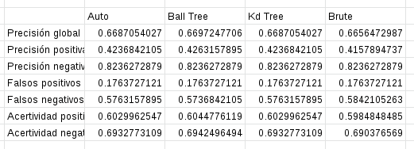

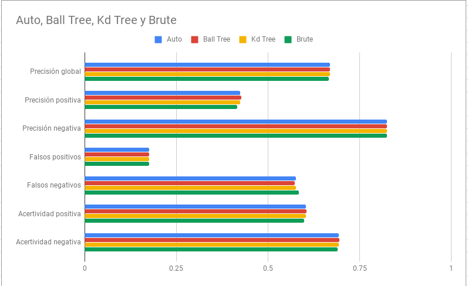

#### ¿Cuál método es mejor?

Los metodos son muy similares en sus resultados, sin embargo parece que el metodo ball tree es ligeramente superior

#### Pregunta 3: [40 puntos]

Reconocimiento Facial. En este ejercicio usaremos el archivo de datos 8carasFamosas.csv el cual contiene 1176 fotos (individuos) de 8 personas diferentes y 2915 variables, donde las primeras 2914 variables representan un pixel de la foto y la variable restante es la variable a predecir, es decir, el nombre de la persona. Es decir, se tienen 2914 variables que son los pixeles de la foto, cada fila representa realmente una matriz de 47 × 62, solamente que fue “estirada” en 47 × 62 = 2914 variables.

#### b-) Genere en Python la tabla de testing con el 20 % de los datos y con el resto de los datos genere una tabla de aprendizaje.

```python
os.chdir("/home/denis/git_projects/MineriaDatos/csv/")
datos = pd.read_csv('8carasFamosas.csv',delimiter=';',decimal=".")

X = datos.iloc[:,0:2914]
print(X.head())

y = datos.iloc[:,2914:2915]
print(y.head())


X_train, X_test, y_train, y_test = train_test_split(X, y, test_size=0.20, random_state=0)
```

```
         pix1        pix2        pix3        pix4        pix5        pix6  \
0  155.666672  152.333328  150.666672  154.333328  155.333328  130.000000
1  160.333328  128.666672   93.000000   65.000000   48.333332   44.000000
2   24.333334   20.333334   17.333334   16.000000   33.333332   55.333332
3   57.000000  147.000000  197.000000  209.666672  228.333328  237.666672
4   12.666667   62.666668  158.333328  189.000000  183.666672  183.333328

         pix7        pix8        pix9       pix10  ...     pix2905  \
0   83.333336   60.000000   61.666668   67.333336  ...  156.333328
1   34.333332   40.666668   99.000000  131.666672  ...  168.333328
2   59.000000   54.666668   39.000000   27.000000  ...  230.000000
3  233.333328  224.666672  181.333328  143.333328  ...  147.000000
4  182.333328  178.000000  174.333328  172.666672  ...  183.666672

      pix2906     pix2907     pix2908     pix2909     pix2910     pix2911  \
```

[output cut: 20 more lines]

#### c-) Usando todos los K Vecinos más Cercanos genere modelo predictivos para la tabla de aprendizaje usando todos los diferentes algoritmos posibles, es decir, el parámetro algorithm variando en auto, ball tree, kd tree y brute.

```python
instancia_knnAuto = KNeighborsClassifier(n_neighbors=3, algorithm='auto')
instancia_knnAuto.fit(X_train,y_train.values.ravel())
prediccionAuto = instancia_knnAuto.predict(X_test)
MCAuto = confusion_matrix(y_test, prediccionAuto)




instancia_knnBallTree = KNeighborsClassifier(n_neighbors=3, algorithm='ball_tree')
instancia_knnBallTree.fit(X_train,y_train.values.ravel())
prediccionBallTree = instancia_knnBallTree.predict(X_test)
MCBallTree = confusion_matrix(y_test, prediccionBallTree)




instancia_knnKdTree = KNeighborsClassifier(n_neighbors=3, algorithm='kd_tree')
instancia_knnKdTree.fit(X_train,y_train.values.ravel())
prediccionKdTree = instancia_knnKdTree.predict(X_test)
MCKdTree = confusion_matrix(y_test, prediccionKdTree)




instancia_knnBrute = KNeighborsClassifier(n_neighbors=3, algorithm='brute')
instancia_knnBrute.fit(X_train,y_train.values.ravel())
prediccionBrute = instancia_knnBrute.predict(X_test)
MCBrute = confusion_matrix(y_test, prediccionBrute)
```

#### d-) Usando la función indices general(...) vista en clase para la tabla de testing calcule las matrices de confusión y plotee dichas matrices usando la función plot confusion matrix(...) cuyo código viene más abajo y pueden bajar el archivo plot confusion matrix.py del aula virtual.

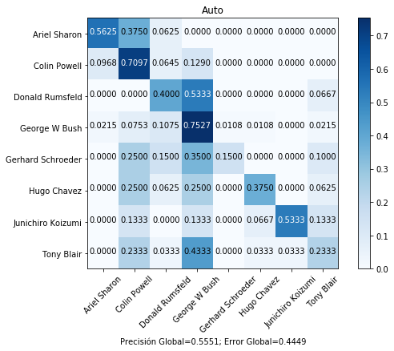

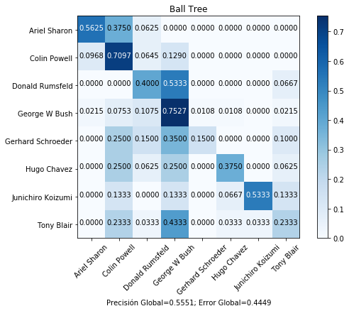

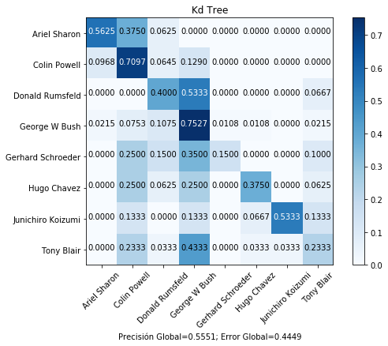

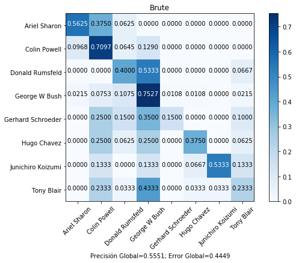

```python
def indices_general(MC, nombres = None):
    precision_global = np.sum(MC.diagonal()) / np.sum(MC)
    error_global = 1 - precision_global
    precision_categoria  = pd.DataFrame(MC.diagonal()/np.sum(MC,axis = 1)).T
    if nombres!=None:
        precision_categoria.columns = nombres
    return {"Matriz de Confusión":MC,
            "Precisión Global":precision_global,
            "Error Global":error_global,
            "Precisión por Categoría":precision_categoria}

os.chdir('/home/denis/git_projects/MineriaDatos/Tarea 6/')
from plot_confusion_matrix import plot_confusion_matrix

indicesAuto = indices_general(MCAuto)
plot_confusion_matrix(indicesAuto['Matriz de Confusión'],list(np.unique(y)), "Auto")

indicesBallTree = indices_general(MCBallTree)
plot_confusion_matrix(indicesBallTree['Matriz de Confusión'],list(np.unique(y)), "Ball Tree")


indicesKdTree = indices_general(MCKdTree)
plot_confusion_matrix(indicesKdTree['Matriz de Confusión'],list(np.unique(y)), "Kd Tree")


indicesBrute = indices_general(MCBrute)
plot_confusion_matrix(indicesBrute['Matriz de Confusión'],list(np.unique(y)), "Brute")
```